# Your Digest for Sunday, Apr 28, 2024 11:59 PM

In ulnar claw hand, the lesion is similar to klumpke's but limited to the medial two fingers.

[output not shown]

- **Erythema nodosum** and erythema multiforme , superficial thrombophlebitis can occur.

> ST depressions cannot be localized. [Source](https://ecgwaves.com/ischemic-changes-in-the-st-segment-and-t-wave/) and [Source](https://litfl.com/st-depression-does-not-localise/)  
> It starts with cartilage **chrondomalacia** - breakdown of the cartilage.  
> Underlying bone becomes exposed -> leads to **eburnation**.  
> There is also **subchondral** thickening - Sclerosis.  
> Pieces of bone break off and float around -> joint **mice**  
> Advanced cases show **osteophyte** formation, subchondral bone cysts, and subchondral sclerosis.  
> Disease process is mediated by inflammatory mediators but is **mainly a degenerative process**, not an inflammatory process.
- Chondrocytes responds to stress in such as way that **cartilage matrix is broken down**.
- Synovial fluid **cysts occur** in the subchondral bone.
- Synovial fluid is **viscous** with **leukocytes**.

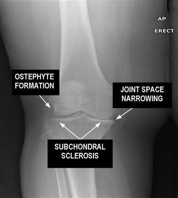

[output not shown]

```
- **Commonly affected**; causes **functional impairment**, especially after rotator cuff tears (which occur in RA).
- **Anaemia** is *universal*: Normochromic, normocytic.
```

> - *Low dose therapy* can cause GI side effects, **rash** on elbows and knees, alopecia and *lung toxicity* and macrocytosis (or isolated ⬇Hb, ⬇PLT or ⬇WBC)  
>   Chloroquine - **used when other treatments have failed**.

[output not shown]

- Purple
- Undermined edge

[figure not shown]